# **Data Analysis Report**

TheDataAreClean

28th March, ’20

### **Background**

Increase visibility into budgets data in India to improve civic participation.

- Citizens have limited access to data on government budgets in India.
- The state budget documents are not easily consumable with detailed information locked in closed formats (PDF, etc.).
- Lack of metadata hinders the process of easy search-ability for relevant fiscal data.
- Restricted public engagement with fiscal data leads constrained public participation with fiscal issues.

### **Objective**

Analysis of Himachal Pradesh state budgetary and district spending expenditure data.

- Comparative analysis for a sector of choice (Primary Education, Public Health or other).
- Identify some key fund flow issues and/or interesting data insights/stories.
- Use open-source softwares like Python, R, LibreOffice Calc or more, to keep the output shareable giving options to collate collaborative feedback.

### **Information**

#### **Related Blogs**

Existing work at CivicDataLab:

- [Tracking Flow of Public Funds through Open Data](https://medium.com/civicdatalab/tracking-flow-of-public-funds-through-open-data-1ace0e5b6163)
- [Roadmap for co-creating the Fiscal Data Explorer](https://medium.com/civicdatalab/roadmap-for-co-creating-the-fiscal-data-explorer-79818a53728f)
- [Design Research for Fiscal Data Explorer - A Work in Progress](https://medium.com/civicdatalab/design-research-for-fiscal-data-explorer-a-work-in-progress-43a07275b1c1)
- [Selecting schemes and sectors for Himachal Pradesh Fiscal Data Explorer - Process and Criteria](https://blog.openbudgetsindia.org/selecting-schemes-and-sectors-for-himachal-fiscal-data-explorer-process-and-criteria-de711f578166)

#### **Extended Reading list**

In-case one wishes to dig deeper, an [extended reading list](https://docs.google.com/document/d/1WYHy_7FLYI84XvXzcW277sqY2oA59zQFAcvbCVbJcR8/edit) explaining some of the key concepts of public finance in India and associated data.

### **Contents**

This report will cover the following areas:

1. **Data Health**
2. **Overall Analysis**
3. **Sector Analysis**
4. **Further Questions**
5. **Additional Ideas**
6. **Challenge**

### **Data Health Report**

#### **Files Recieved**

As a part of the assignment, 4 data files in `.csv` format were provided were provided and 2 metadata files in `.xlsx` format with descriptions of the data file fields.

```r
# Data files for the assignment
dir("../data/raw/")
```

```
## [1] "budget_expenditure_fy_2017_18.csv"
## [2] "budget_expenditure_fy_2018_19.csv"
## [3] "district_spending_expenditure_fy_2017_18.csv"
## [4] "district_spending_expenditure_fy_2018_19.csv"
```

```r
# Metadata files for the assignment
dir("../data/metadata/")
```

```
## [1] "Metadata Himachal Budget Allocation.xlsx"
## [2] "Metadata Himachal Spending Expendiure.xlsx"
```

#### **Details**

**Datasets** *State Budget Expenditures* & *District Spending Expenditures* for FY 2017-18 & FY 2018-19

**Information** *State Budget Expenditure*: Information like Account Heads, Statement of Expenditure, Sanctions, Revisions;

*District Spending Expenditures*: Information like District, Treasury, DDO, Account Heads, Statement of Expenditure, Gross and Net Payments.

### **Overall Analysis**

#### **Read**

Read the cleaned dataset after processing through the Data Health Report

```r
# State expenditure data
budget_exp_final <- read_csv("../data/processed/budget_exp_final.csv")

# Distirct spending data
district_spending_exp_final <- read_csv("../data/processed/district_spending_exp_final.csv")
```

#### **Clean**

Normalize the data fields across files for analysis.

```r
# Format the monetary value fields
# State Budget Expenditure
budget_exp_final$sanction <- accounting(budget_exp_final$sanction)
budget_exp_final$addition <- accounting(budget_exp_final$addition)
budget_exp_final$savings <- accounting(budget_exp_final$savings)
budget_exp_final$revised <- accounting(budget_exp_final$revised)

# District Spending  Expenditure
district_spending_exp_final$gross <- accounting(district_spending_exp_final$gross)
district_spending_exp_final$agded <- accounting(district_spending_exp_final$agded)
district_spending_exp_final$btded <- accounting(district_spending_exp_final$btded)
district_spending_exp_final$net_payment <- accounting(district_spending_exp_final$net_payment)
```

#### **State Budget Expenditure**

```r
# Quick Summary
state_budget_summary <- budget_exp_final %>%
                            group_by(year) %>%
                            summarise(sanction = sum(sanction),
                                      revised = sum(revised))

# Rename Fields
names(state_budget_summary) <- c("Fiscal Year", "Sanction", "Revised")

# Print formatted Table
formattable(state_budget_summary, list(
                                    Sanction = color_bar("orange"),
                                    Revised = color_bar("lightgreen")
                                    )
            )
```

| Fiscal Year | Sanction | Revised |
| --- | --- | --- |
| 2017-18 | 1,394,299,171.45 | 1,355,314,609.15 |
| 2018-19 | 1,596,963,894.14 | 1,517,818,288.40 |

- For the year 2018-19; the sanctioned budget was 1.59 Bn. & the revised budget was 1.51Bn.
- ~14.5% increase in the sanctioned state budget in the year 2018-19 over 2017-18.
- The revised state budget for 2018-17 was ~95% of the original sanctioned budget; and ~97.2% in 2017-18.

##### **Top Account Heads**

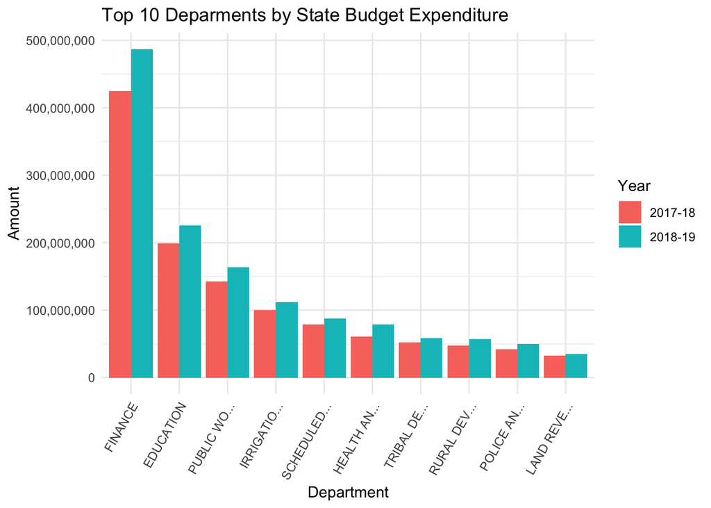

```r
# Account Head Wise spending
state_budget_demand <- budget_exp_final %>%
                            group_by(year, demand_desc) %>%
                            summarise(sanction = sum(sanction)) %>%
                            spread(year, sanction, fill = 0) %>%
                            arrange(desc(`2018-19`)) %>%
                            mutate(`Total Sanction (2018-19)` = sum(`2018-19`),
                                   `Total Sanction (2017-18)` = sum(`2017-18`)) %>%
                            mutate(`% of Total (2018-19)` = formattable::percent(`2018-19`/`Total Sanction (2018-19)`),
                                   `% of Total (2017-18)` = formattable::percent(`2017-18`/`Total Sanction (2017-18)`)) %>%
                            select(demand_desc, `2018-19`, `% of Total (2018-19)`, `2017-18`, `% of Total (2017-18)`)

# Rename Fields
colnames(state_budget_demand)[1] <- "Demand"

# Plot bar chart for representation
# Absolutes
state_budget_demand %>%
        select(Demand, `2018-19`, `2017-18`) %>%
        head(10) %>%
        gather(Year, Amount, -Demand) %>%
        mutate(Demand = as_factor(Demand)) %>%
        ggplot(aes(x = Demand, y = Amount, fill = Year)) +
            geom_bar(stat = "identity", position = position_dodge()) +
            scale_x_discrete(label = function(x) stringr::str_trunc(x, 12)) +
            scale_y_continuous(labels = comma) +
            labs(title = "Top 10 Deparments by State Budget Expenditure", x = "Department", y = "Amount") +
            theme_minimal() + theme(axis.text.x = element_text(angle = 60, vjust = 1, hjust = 1))
```

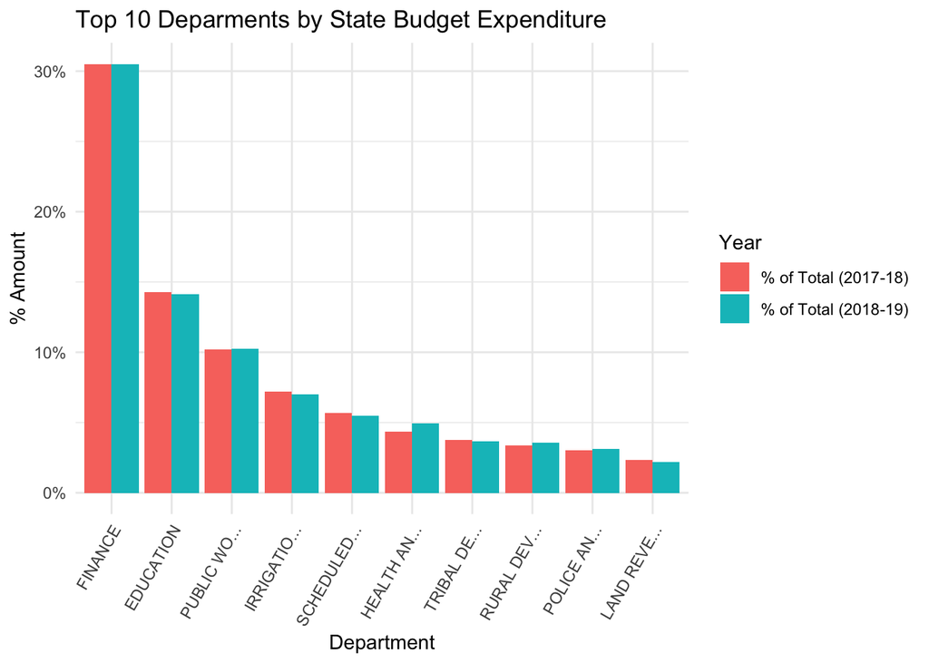

```r
# Percentage
state_budget_demand %>%
        select(Demand, `% of Total (2018-19)`, `% of Total (2017-18)`) %>%
        head(10) %>%
        gather(Year, Amount, -Demand) %>%
        mutate(Demand = as_factor(Demand)) %>%
        ggplot(aes(x = Demand, y = Amount, fill = Year)) +
            geom_bar(stat = "identity", position = position_dodge()) +
            scale_x_discrete(label = function(x) stringr::str_trunc(x, 12)) +
            scale_y_continuous(labels = percent) +
            labs(title = "Top 10 Deparments by State Budget Expenditure", x = "Department", y = "% Amount") +
            theme_minimal() + theme(axis.text.x = element_text(angle = 60, vjust = 1, hjust = 1))
```

- Finance was alloyed the highest amount of all account heads, 30.49% of total sanctioned expenditure for the year; followed by Education with 14.12% & Public Works – Roads Bridges & Buildings at 10.26%
- This trend has followed form 2017-18 in terms of priority for the state budget allocations.

##### **Voted vs Charged**

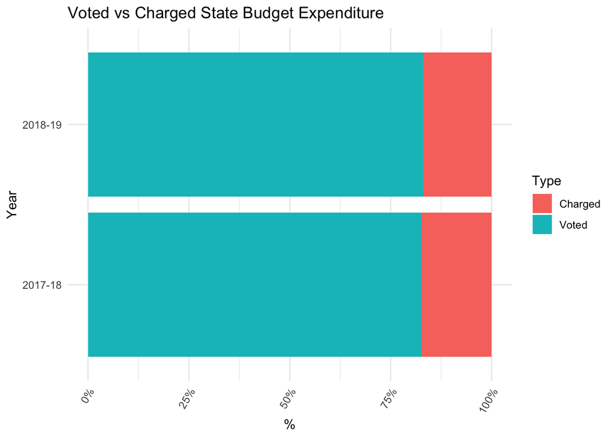

```r
# Voted/Charged
budget_exp_final %>%
        group_by(year, voted_charged) %>%
        summarise(sanction = sum(sanction)) %>%
        spread(voted_charged, sanction) %>%
        mutate(percent_charged = formattable::percent(C/(V+C)),
               percent_voted = formattable::percent(V/(V+C))) %>%
        select(year, percent_voted, percent_charged) %>%
        gather(Bucket, Percentage, -year) %>%
        ggplot(aes(x = year, y = Percentage, fill = Bucket)) +
                geom_bar(stat = "identity", position = "stack") +
                scale_y_continuous(labels = percent) +
                scale_fill_discrete(name = "Type", labels = c("Charged", "Voted")) +
                labs(title = "Voted vs Charged State Budget Expenditure", x = "Year", y = "%") +
                theme_minimal() + theme(axis.text.x = element_text(angle = 60, vjust = 1, hjust = 1)) +
                coord_flip()
```

~83% of all State Budget Expenditure is Voted for, remaining 17% is charged.

##### **Plan vs Non-Plan**

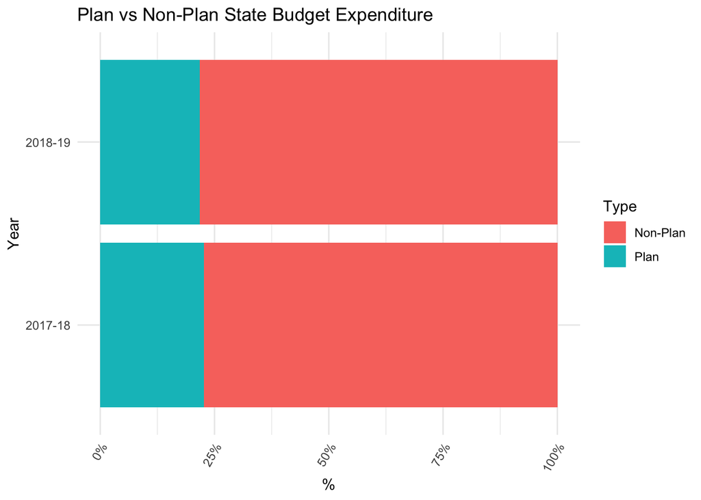

```r
# Plan/Non-Plan
budget_exp_final %>%
        group_by(year, plan_nonplan) %>%
        summarise(sanction = sum(sanction)) %>%
        spread(plan_nonplan, sanction) %>%
        mutate(percent_plan = formattable::percent(P/(N+P)),
               percent_nonplan = formattable::percent(N/(N+P))) %>%
        select(year, percent_plan, percent_nonplan) %>%
        gather(Bucket, Percentage, -year) %>%
        ggplot(aes(x = year, y = Percentage, fill = Bucket)) +
                geom_bar(stat = "identity", position = "stack") +
                scale_y_continuous(labels = percent) +
                scale_fill_discrete(name = "Type", labels = c("Non-Plan", "Plan")) +
                labs(title = "Plan vs Non-Plan State Budget Expenditure", x = "Year", y = "%") +
                theme_minimal() + theme(axis.text.x = element_text(angle = 60, vjust = 1, hjust = 1)) +
                coord_flip()
```

Over 78% of all State Budget expenditure is Non-Plan, and remaining ~22% under Plan.

##### **YoY Comparison**

Changes in allotments in State Budget accross departments b/w 2018-19 and 2017-18.

```r
# Overall Top 10 Investments
# Absolute change in account heads expenditure
state_budget_top_account_changes_absolute <- budget_exp_final %>%
                                                group_by(year, demand_desc) %>%
                                                summarise(sanction = sum(sanction)) %>%
                                                spread(year, sanction, fill = 0) %>%
                                                mutate(delta = `2018-19` - `2017-18`,
                                                      percent_delta = formattable::percent((`2018-19` - `2017-18`)/`2017-18`)) %>%
                                                select(demand_desc, delta, percent_delta) %>%
                                                arrange(desc(delta)) %>%
                                                head(5)

# Rename Fields
names(state_budget_top_account_changes_absolute) <- c("Department", "Change", "% Change")

# Print formatted Table
formattable(state_budget_top_account_changes_absolute, list(
                                                            Change = color_bar("lightgreen"),
                                                            `% Change` = color_tile("paleturquoise", "turquoise")
                                                            )
            )
```

| Department | Change | % Change |
| --- | --- | --- |
| FINANCE | 61,694,755.62 | 14.51% |
| EDUCATION | 26,477,716.05 | 13.30% |
| PUBLIC WORKS – ROADS BRIDGES AND BUILDINGS | 21,385,898.95 | 15.02% |
| HEALTH AND FAMILY WELFARE | 18,036,330.12 | 29.61% |
| IRRIGATION WATER SUPPLY AND SANITATION | 11,477,923.50 | 11.43% |

```r
# % change in account heads expenditure
state_budget_top_account_changes_percent <- budget_exp_final %>%
                                                group_by(year, demand_desc) %>%
                                                summarise(sanction = sum(sanction)) %>%
                                                spread(year, sanction, fill = 0) %>%
                                                mutate(delta = `2018-19` - `2017-18`,
                                                      percent_delta = formattable::percent((`2018-19` - `2017-18`)/`2017-18`)) %>%
                                                select(demand_desc, delta, percent_delta) %>%
                                                arrange(desc(percent_delta)) %>%
                                                head(5)

# Rename Fields
names(state_budget_top_account_changes_percent) <- c("Department", "Change", "% Change")

# Print formatted Table
formattable(state_budget_top_account_changes_percent, list(
                                                        Change = color_bar("lightgreen"),
                                                        `% Change` = color_tile("paleturquoise", "turquoise")
                                                        )
            )
```

| Department | Change | % Change |
| --- | --- | --- |
| TOURISM AND CIVIL AVIATION | 1,718,133.98 | 61.84% |
| INDUSTRIES MINERALS SUPPLIES AND INFORMATION TECHNOLOGY | 3,134,049.97 | 52.77% |
| AGRICULTURE | 5,112,741.30 | 34.04% |
| HEALTH AND FAMILY WELFARE | 18,036,330.12 | 29.61% |
| VIDHAN SABHA | 365,284.40 | 29.36% |

- Finance, Education & Public Works has seen the most increase in absolute sanctions numbers in 2018-19 over 2017-18.
- Tourism and Civil Aviation (61.84%), Industries Mineral Supplies and Information Technology (52.77%) and Agriculture (34.04%) have seen highest sanctions in terms of % change.

```r
# Overall Top 10 Disinvestments
# Absolute change in account heads expenditure
state_budget_bottom_account_changes_absolute <- budget_exp_final %>%
                                                    group_by(year, demand_desc) %>%
                                                    summarise(sanction = sum(sanction)) %>%
                                                    spread(year, sanction, fill = 0) %>%
                                                    mutate(delta = `2018-19` - `2017-18`,
                                                          percent_delta = formattable::percent((`2018-19` - `2017-18`)/`2017-18`)) %>%
                                                    select(demand_desc, delta, percent_delta) %>%
                                                    arrange(delta) %>%
                                                    head(2)

# Rename Fields
names(state_budget_bottom_account_changes_absolute) <- c("Department", "Change", "% Change")

# Print formatted Table
formattable(state_budget_bottom_account_changes_absolute, list(
                                                            Change = color_bar("lightgreen"),
                                                            `% Change` = color_tile("paleturquoise", "turquoise")
                                                            )
            )
```

| Department | Change | % Change |
| --- | --- | --- |
| LABOUR EMPLOYMENT AND TRAINING | (3,953,494.88) | -23.19% |
| ELECTION | (542,190.82) | -37.58% |

Election (37.58%), Labour Employment and Training (23.19%) have seen highest decrease sanctions in terms of % change.

##### **Sanction vs Revised**

Comparison of sanction vs revised 2018-19 State Budget Expenditure to understand departments with most changes.

```r
## 2018-19 positive absolute change
state_budget_postive_change_absolute <- budget_exp_final %>%
                                            filter(year == "2018-19") %>%
                                            group_by(demand_desc) %>%
                                            summarise(sanction = sum(sanction),
                                                      revised = sum(revised)) %>%
                                            mutate(revision_delta = (revised - sanction),
                                                   percent_delta =  formattable::percent((revised - sanction)/sanction)) %>%
                                            arrange(desc(revision_delta)) %>%
                                            select(demand_desc, revision_delta, percent_delta) %>%
                                            head(5)

# Rename Fields
names(state_budget_postive_change_absolute) <- c("Department", "Change", "% Change")

# Print formatted Table
formattable(state_budget_postive_change_absolute, list(
                                                    Change = color_bar("gold"),
                                                    `% Change` = color_tile("violet", "darkviolet")
                                                    )
            )
```

| Department | Change | % Change |
| --- | --- | --- |
| LAND REVENUE AND DISTRICT ADMINISTRATION | 14,489,694.36 | 41.54% |
| FINANCE | 8,382,910.02 | 1.72% |
| IRRIGATION WATER SUPPLY AND SANITATION | 6,249,680.22 | 5.59% |
| POWER DEVELOPMENT | 3,228,706.96 | 9.43% |
| MISCELLANEOUS GENERAL SERVICES | 2,835,994.88 | 55.74% |

```r
## 2018-19 positive percent change
state_budget_postive_change_percent <- budget_exp_final %>%
                                            filter(year == "2018-19") %>%
                                            group_by(demand_desc) %>%
                                            summarise(sanction = sum(sanction),
                                                      revised = sum(revised)) %>%
                                            mutate(revision_delta = (revised - sanction),
                                                   percent_delta =  formattable::percent((revised - sanction)/sanction)) %>%
                                            arrange(desc(percent_delta)) %>%
                                            select(demand_desc, revision_delta, percent_delta) %>%
                                            head(5)


# Rename Fields
names(state_budget_postive_change_percent) <- c("Department","Change", "% Change")

# Print formatted Table
formattable(state_budget_postive_change_percent, list(
                                                    Change = color_bar("gold"),
                                                    `% Change` = color_tile("violet", "darkviolet")
                                                    )
            )
```

| Department | Change | % Change |
| --- | --- | --- |
| COOPERATION | 1,303,384.62 | 107.47% |
| ELECTION | 669,692.76 | 74.37% |
| MISCELLANEOUS GENERAL SERVICES | 2,835,994.88 | 55.74% |
| LAND REVENUE AND DISTRICT ADMINISTRATION | 14,489,694.36 | 41.54% |
| FOOD AND CIVIL SUPPLIES | 2,421,327.50 | 25.38% |

- Land Revenue and District Administration & Finance saw one of the highest increase from sanctions to revisions.
- Both financial years saw over huge increases in election expenditure from sanctions to revised 74.37% in 2018-19.

```r
## 2018-19 negative absolute change
state_budget_negative_change_absolute <- budget_exp_final %>%
                                            filter(year == "2018-19") %>%
                                            group_by(demand_desc) %>%
                                            summarise(sanction = sum(sanction),
                                                      revised = sum(revised)) %>%
                                            mutate(revision_delta = (revised - sanction),
                                                   percent_delta =  formattable::percent((revised - sanction)/sanction)) %>%
                                            arrange(revision_delta) %>%
                                            select(demand_desc, revision_delta, percent_delta) %>%
                                            head(5)

# Rename Fields
names(state_budget_negative_change_absolute) <- c("Department", "Change", "% Change")

# Print formatted Table
formattable(state_budget_negative_change_absolute, list(
                                                    Change = color_bar("gold"),
                                                    `% Change` = color_tile("violet", "darkviolet")
                                                    )
            )
```

| Department | Change | % Change |
| --- | --- | --- |
| EDUCATION | (34,317,556.56) | -15.22% |
| SCHEDULED CASTES SUB PLAN | (19,131,312.66) | -21.92% |
| PUBLIC WORKS – ROADS BRIDGES AND BUILDINGS | (14,856,371.40) | -9.07% |
| TRIBAL DEVELOPMENT | (14,115,871.44) | -24.07% |
| RURAL DEVELOPMENT | (13,951,179.54) | -24.55% |

```r
## 2018-19 positive percent change
state_budget_negative_change_percent <- budget_exp_final %>%
                                            filter(year == "2018-19") %>%
                                            group_by(demand_desc) %>%
                                            summarise(sanction = sum(sanction),
                                                      revised = sum(revised)) %>%
                                            mutate(revision_delta = (revised - sanction),
                                                   percent_delta =  formattable::percent((revised - sanction)/sanction)) %>%
                                            arrange(percent_delta) %>%
                                            select(demand_desc, revision_delta, percent_delta) %>%
                                            head(5)


# Rename Fields
names(state_budget_negative_change_percent) <- c("Department", "Change", "% Change")

# Print formatted Table
formattable(state_budget_negative_change_percent, list(
                                                    Change = color_bar("gold"),
                                                    `% Change` = color_tile("violet", "darkviolet")
                                                    )
            )
```

| Department | Change | % Change |
| --- | --- | --- |
| INDUSTRIES MINERALS SUPPLIES AND INFORMATION TECHNOLOGY | (4,041,089.26) | -44.54% |
| RURAL DEVELOPMENT | (13,951,179.54) | -24.55% |
| TRIBAL DEVELOPMENT | (14,115,871.44) | -24.07% |
| FOREST AND WILD LIFE | (4,772,238.76) | -23.82% |
| SCHEDULED CASTES SUB PLAN | (19,131,312.66) | -21.92% |

- Education saw the highest decrease from sanction to revised in both years with 34 Mn, ~15.22% in 2018-19.
- Scheduled Castes Sub Plan, Rural Development, Tribal Development all saw decreases from sanction to revised.

#### **District Spending Expenditure**

##### **Overall**

```r
# Quick Summary
district_spending_summary <- district_spending_exp_final %>%
                                group_by(year) %>%
                                summarise(gross = sum(gross),
                                net_payment = sum(net_payment))

# Rename Fields
names(district_spending_summary) <- c("Fiscal Year", "Gross", "Net Payment")

# Print formatted Table
formattable(district_spending_summary, list(
                                            Gross = color_bar("orange"),
                                            `Net Payment` = color_bar("lightgreen")
                                            )
            )
```

| Fiscal Year | Gross | Net Payment |
| --- | --- | --- |
| 2017-18 | 338,610,175,775.00 | 293,619,324,130.00 |
| 2018-19 | 374,539,373,671.00 | 330,887,593,373.00 |

The net payments amount for Himachal Pradesh in 2018-19 was 330.9 Bn.; a 12.7% increase over the previous years District Spending.

##### **Spending Over Time**

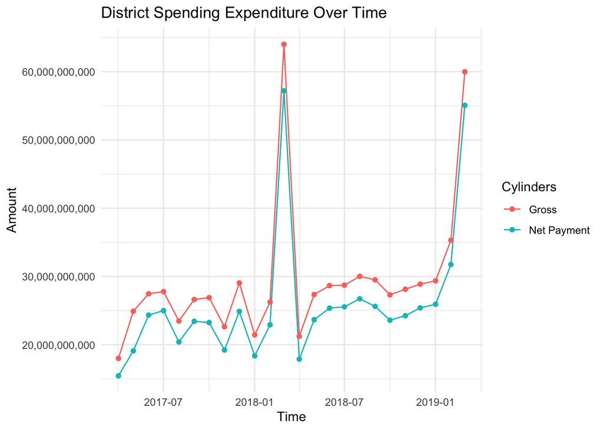

```r
# Trends for budget allocation over time
district_spending_exp_final %>%
    mutate(month = floor_date(transaction_date, unit = "month")) %>%
    group_by(month) %>%
    summarise(gross = sum(gross),
              net_payment = sum(net_payment)) %>%
    gather(type, amount, -month) %>%
    ggplot(aes(x = month, y = amount, color = type)) +
    geom_line() + geom_point() +
    scale_y_continuous(labels = comma) +
    scale_color_discrete(name = "Cylinders", labels = c("Gross", "Net Payment")) +
    labs(title = "District Spending Expenditure Over Time", x = "Time", y = "Amount") +
    theme_minimal()
```

##### **Top Districts & Treasuries**

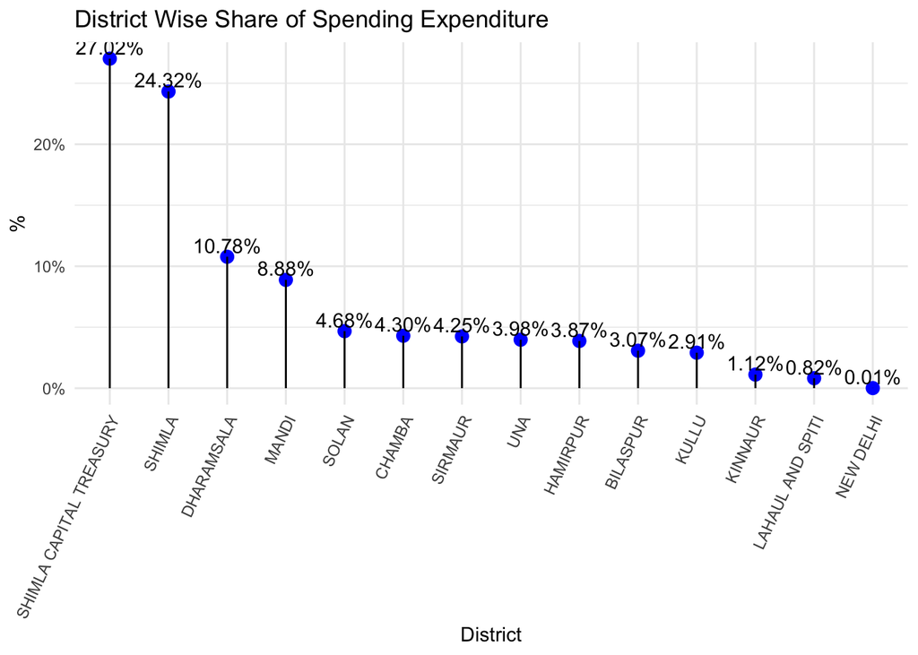

```r
# District Wise spending
district_spending_exp_final %>%
    filter(year == "2018-19") %>%
    group_by(district) %>%
    summarise(net_payment = sum(net_payment)) %>%
    arrange(desc(net_payment)) %>%
    mutate(net_payment_total = sum(net_payment)) %>%
    mutate(net_payment_percent = formattable::percent(net_payment/net_payment_total)) %>%
    select(district, net_payment_percent) %>%
    mutate(district = as_factor(district)) %>%
    ggplot(aes(x = district, y = net_payment_percent, label = net_payment_percent)) +
        geom_point(col = "blue", size = 3) + geom_text(vjust = -0.3) +
        geom_segment(aes(x = district, xend = district, y = 0, yend = net_payment_percent)) +
    scale_y_continuous(labels = percent) +
    labs(title="District Wise Share of Spending Expenditure", x = "District", y = "%") +
    theme_minimal() + theme(axis.text.x = element_text(angle = 65, vjust = 1, hjust = 1))
```

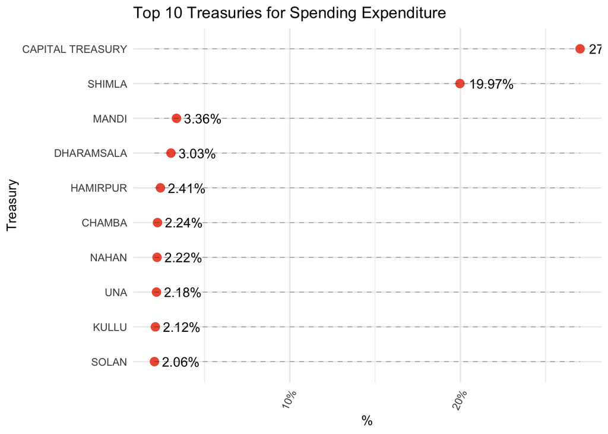

```r
# Treasury Wise spending
district_spending_exp_final %>%
    filter(year == "2018-19") %>%
    group_by(treasury) %>%
    summarise(net_payment = sum(net_payment)) %>%
    arrange(desc(net_payment)) %>%
    mutate(net_payment_total = sum(net_payment)) %>%
    mutate(net_payment_percent = formattable::percent(net_payment/net_payment_total)) %>%
    select(treasury, net_payment_percent) %>%
    head(10) %>%
    mutate(treasury = as_factor(treasury)) %>%
    ggplot(aes(x = reorder(treasury, desc(treasury)),
               y = net_payment_percent,
               label = net_payment_percent)) +
        geom_point(col = "tomato2", size = 3) + geom_text(hjust = -0.2) +
        geom_segment(aes(x = treasury, xend = treasury,
                         y = min(net_payment_percent), yend = max(net_payment_percent)),
                     linetype = "dashed", size = 0.1) +
    scale_y_continuous(labels = percent) +
    labs(title="Top 10 Treasuries for Spending Expenditure", x = "Treasury", y = "%") +
    theme_minimal() + theme(axis.text.x = element_text(angle = 65, vjust = 1, hjust = 1)) +
    coord_flip()
```

##### **Top Account Heads**

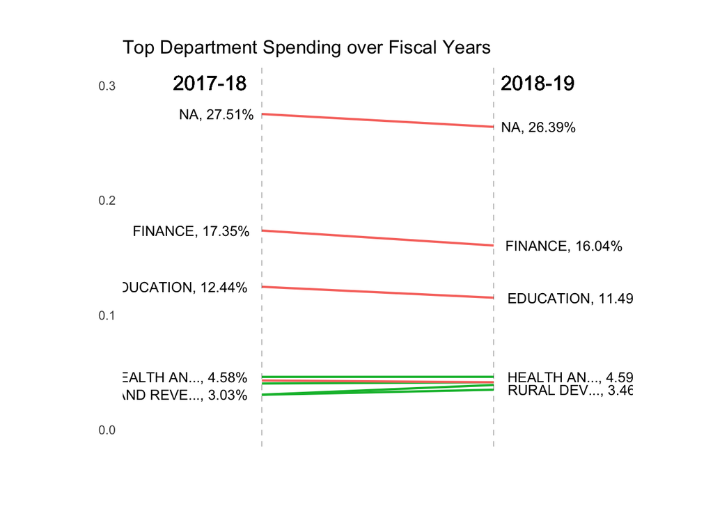

```r
# Account Head wise spending
district_spending_account_yoy <- district_spending_exp_final %>%
                                    group_by(year, demand_desc) %>%
                                    summarise(net_payment = sum(net_payment)) %>%
                                    spread(year, net_payment, fill = 0) %>%
                                    arrange(desc(`2018-19`)) %>%
                                    mutate(net_payment_18_19 = sum(`2018-19`),
                                           net_payment_17_18 = sum(`2017-18`)) %>%
                                    mutate(net_payment_18_19_percent =
                                               formattable::percent(`2018-19`/net_payment_18_19),
                                           net_payment_17_18_percent =
                                               formattable::percent(`2017-18`/net_payment_17_18)) %>%
                                    select(demand_desc, net_payment_18_19_percent, net_payment_17_18_percent) %>%
                                    head(8)

# Plot the major account heds
# Prep Data
left_label <- paste(stringr::str_trunc(district_spending_account_yoy$demand_desc, 12),
                    district_spending_account_yoy$net_payment_17_18_percent,sep = ", ")
right_label <- paste(stringr::str_trunc(district_spending_account_yoy$demand_desc, 12),
                     district_spending_account_yoy$net_payment_18_19_percent,sep=", ")
district_spending_account_yoy$class <- ifelse((
    district_spending_account_yoy$net_payment_18_19_percent -
        district_spending_account_yoy$net_payment_17_18_percent) < 0, "red", "green")

# Plot
p <- ggplot(district_spending_account_yoy) +
        geom_segment(aes(x = 1, xend = 2,
                         y = net_payment_17_18_percent, yend = net_payment_18_19_percent,
                         col = class), size=.75, show.legend = F) +
                    geom_vline(xintercept = 1, linetype = "dashed", size = .1) +
                    geom_vline(xintercept = 2, linetype = "dashed", size = .1) +
                    scale_color_manual(labels = c("Up", "Down"),
                                       values = c("green" = "#00ba38", "red" = "#f8766d")) +
                    labs(x = "", y = "", title = "Top Department Spending over Fiscal Years") +
                    xlim(.5, 2.5) +
                    ylim(0,(1.1*(max(district_spending_account_yoy$net_payment_17_18_percent,
                                     district_spending_account_yoy$net_payment_18_19_percent)))) +
                    theme_minimal()

# Add texts
p <- p + geom_text(label = left_label, check_overlap = TRUE,
                   y = district_spending_account_yoy$net_payment_17_18_percent,
                   x = rep(1, NROW(district_spending_account_yoy)),
                   hjust = 1.1, size = 3.5)

p <- p + geom_text(label = right_label,  check_overlap = TRUE,
                   y = district_spending_account_yoy$net_payment_18_19_percent,
                   x = rep(2, NROW(district_spending_account_yoy)),
                   hjust = -0.1, size = 3.5)

p <- p + geom_text(label="2017-18",
                   x = 1,
                   y = 1.1*(max(district_spending_account_yoy$net_payment_17_18_percent,
                                district_spending_account_yoy$net_payment_18_19_percent)),
                   hjust = 1.2, size = 5)  # title

p <- p + geom_text(label="2018-19",
                   x = 2,
                   y = 1.1*(max(district_spending_account_yoy$net_payment_17_18_percent,
                                district_spending_account_yoy$net_payment_18_19_percent)),
                   hjust = -0.1, size = 5)  # title

# Minify theme
p + theme(panel.background = element_blank(),
           panel.grid = element_blank(),
           axis.ticks = element_blank(),
           axis.text.x = element_blank(),
           panel.border = element_blank(),
           plot.margin = unit(c(1,2,1,2), "cm"))
```

Finance (16.04%), Education (11.49%) and Health and Family Welfare (4.59%) have the highest amount of net payments across both financial years.

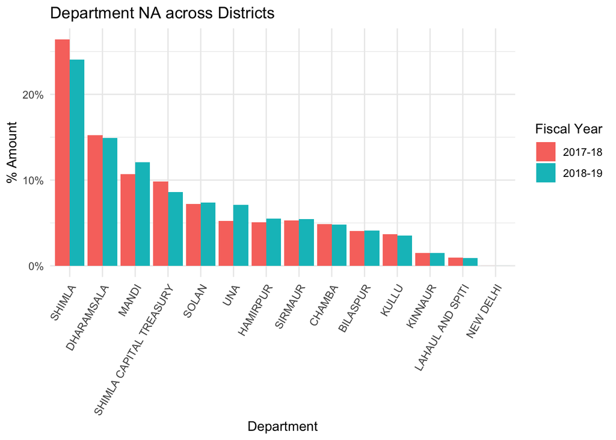

```r
# Demand Description is NA
district_spending_exp_final %>%
    filter(is.na(demand_desc)) %>%
    group_by(year, district) %>%
    summarise(net_payment = sum(net_payment)) %>%
    spread(year, net_payment, fill = 0) %>%
    arrange(desc(`2018-19`)) %>%
    mutate(net_payment_18_19 = sum(`2018-19`),
           net_payment_17_18 = sum(`2017-18`)) %>%
    mutate(net_payment_18_19_percent =
               formattable::percent(`2018-19`/net_payment_18_19),
           net_payment_17_18_percent =
               formattable::percent(`2017-18`/net_payment_17_18)) %>%
    select(district, net_payment_18_19_percent, net_payment_17_18_percent) %>%
    gather(year, percent, -district) %>%
    mutate(district = as_factor(district)) %>%
    ggplot(aes(x = district, y = percent, fill = year)) +
            geom_bar(stat = "identity", position = position_dodge()) +
            scale_y_continuous(labels = percent) +
            scale_fill_discrete(name = "Fiscal Year", labels = c("2017-18", "2018-19")) +
            labs(title = "Department NA across Districts", x = "Department", y = "% Amount") +
            theme_minimal() + theme(axis.text.x = element_text(angle = 60, vjust = 1, hjust = 1))
```

26.39% of net payments have no Department info against them, when looking at the district data they are spread across all with Shimla at top with 24.06% of the NA spend and Dharamsala at 14.91%.

##### **Change Over Years**

Top 10 departments with change is spending over the 2 fiscal years.

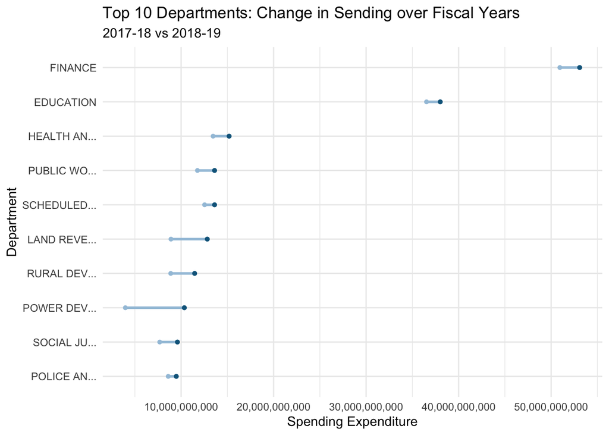

```r
# Abslolute Positive Change in Net Payments
account_head_change_yoy <- district_spending_exp_final %>%
      filter(!is.na(demand_desc)) %>%
      group_by(year, demand_desc) %>%
      summarise(net_payment = sum(net_payment)) %>%
      spread(year, net_payment, fill = 0) %>%
      mutate(delta = `2018-19` - `2017-18`,
             percent_delta = formattable::percent((`2018-19` - `2017-18`)/`2017-18`)) %>%
      select(demand_desc, `2018-19`, `2017-18`, delta, percent_delta) %>%
      arrange(desc(`2018-19`)) %>%
      head(10)

# Ordering of values
account_head_change_yoy$demand_desc <-
              factor(stringr::str_trunc(account_head_change_yoy$demand_desc, 12),
                     levels = rev(as.character(stringr::str_trunc(
                       account_head_change_yoy$demand_desc, 12))
                       )
                     )

# Plotting of values
ggplot(account_head_change_yoy,
         aes(x = `2017-18`, xend = `2018-19`,
             y = demand_desc,
             group = demand_desc)) +
      geom_dumbbell(color = "#a3c4dc",
                    size = 1,
                    colour_xend = "#0e668b") +
      scale_x_continuous(label = comma) +
      labs(x = "Spending Expenditure",
           y = "Department",
           title = "Top 10 Departments: Change in Sending over Fiscal Years",
           subtitle = "2017-18 vs 2018-19") +
      theme_minimal()
```

- Power Development, Land Revenue and District Administration, Rural Development had the highest absolute increase in net payments YoY.
- Power Development (160.48%), Urban Development Town and Country Planning and Housing (77.97%) highest % increase in net payments YoY.

### **Sector Analysis**

Analysis of Education Department entries in the budgetary datasets.

#### **State Budget Expenditure**

##### **Overall**

```r
# Quick Summary
education_state_budget_overall <- budget_exp_final %>%
          filter(demand_desc == "EDUCATION") %>%
          group_by(year) %>%
          summarise(sanction = sum(sanction),
                    revised = sum(revised))

# Rename Fields
names(education_state_budget_overall) <- c("Fiscal Year", "Sanction", "Revised")

# Print formatted Table
formattable(education_state_budget_overall, list(
                                                Sanction = color_bar("orange"),
                                                Revised = color_bar("lightgreen")
                                                )
            )
```

| Fiscal Year | Sanction | Revised |
| --- | --- | --- |
| 2017-18 | 199,041,424.05 | 188,424,599.70 |
| 2018-19 | 225,519,140.10 | 191,201,583.54 |

In 2018-19, the revised education budget was down to 85% of originally sanctioned; compared to 95% in 2017-18.

##### **Account Heads**

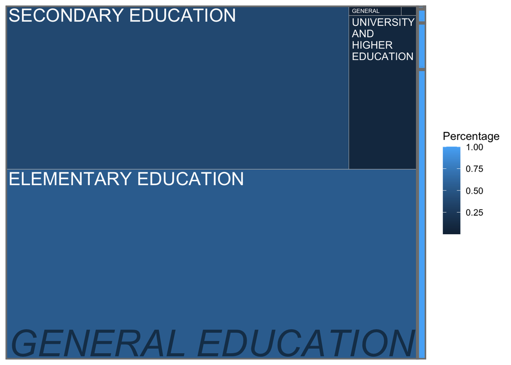

```r
# Major/Sub-Major Expenditure
ed_major_state_expenditure <- budget_exp_final %>%
          filter(demand_desc == "EDUCATION" & year == "2018-19") %>%
          group_by(major_desc, sub_major_desc) %>%
          summarise(sanction = sum(sanction)) %>%
          mutate(total_sanction = sum(sanction)) %>%
          mutate(percent_sanction = formattable::percent(sanction/total_sanction)) %>%
          arrange(desc(sanction))

# Plot the treemap
ggplot(ed_major_state_expenditure,
       aes(area = sanction, fill = percent_sanction,
           label = sub_major_desc, subgroup = major_desc)) +
  geom_treemap() +
  geom_treemap_subgroup_border() +
  scale_fill_continuous(name = "Percentage") +
  geom_treemap_subgroup_text(place = "bottom", grow = T, alpha = 0.5, colour =
                             "black", fontface = "italic", min.size = 0) +
  geom_treemap_text(colour = "white", place = "topleft", reflow = T)
```

- ~98% of all state education expenditure was towards General Education function.
- The top sub-sectors were Elementary Education (53.76%), Secondary Education (38.54%) & University and Higher Education (7.24%).

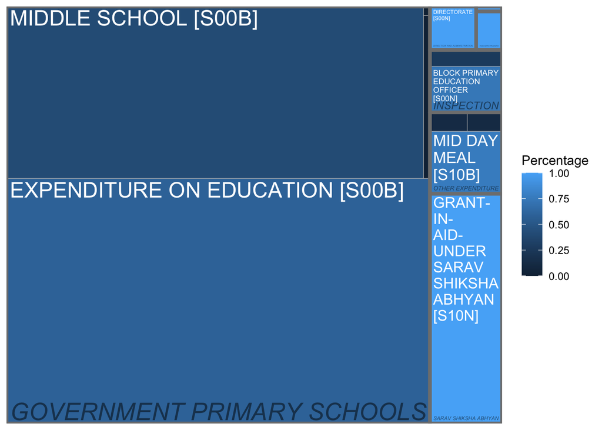

```r
# Major/Sub-Major Expenditure
ed_major_state_expenditure <- budget_exp_final %>%
          filter(demand_desc == "EDUCATION" &
                   year == "2018-19" &
                   sub_major_desc == "ELEMENTARY EDUCATION") %>%
          group_by(minor_desc, sub_minor_desc) %>%
          summarise(sanction = sum(sanction)) %>%
          mutate(total_sanction = sum(sanction)) %>%
          mutate(percent_sanction = formattable::percent(sanction/total_sanction)) %>%
          arrange(desc(sanction))

# Plot the treemap
ggplot(ed_major_state_expenditure,
       aes(area = sanction, fill = percent_sanction,
           label = sub_minor_desc, subgroup = minor_desc)) +
  geom_treemap() +
  geom_treemap_subgroup_border() +
  scale_fill_continuous(name = "Percentage") +
  geom_treemap_subgroup_text(place = "bottom", grow = T, alpha = 0.5, colour =
                             "black", fontface = "italic", min.size = 0) +
  geom_treemap_text(colour = "white", place = "topleft", reflow = T)
```

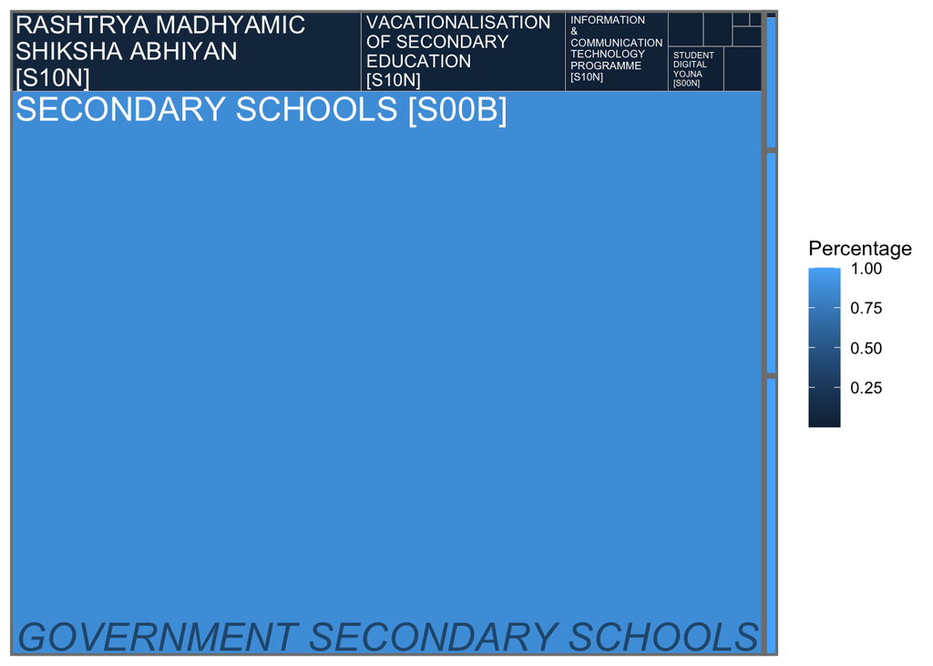

```r
# Major/Sub-Major Expenditure
ed_major_state_expenditure <- budget_exp_final %>%
          filter(demand_desc == "EDUCATION" &
                   year == "2018-19" &
                   sub_major_desc == "SECONDARY EDUCATION") %>%
          group_by(minor_desc, sub_minor_desc) %>%
          summarise(sanction = sum(sanction)) %>%
          mutate(total_sanction = sum(sanction)) %>%
          mutate(percent_sanction = formattable::percent(sanction/total_sanction)) %>%
          arrange(desc(sanction))

# Plot the treemap
ggplot(ed_major_state_expenditure,
       aes(area = sanction, fill = percent_sanction,
           label = sub_minor_desc, subgroup = minor_desc)) +
  geom_treemap() +
  geom_treemap_subgroup_border() +
  scale_fill_continuous(name = "Percentage") +
  geom_treemap_subgroup_text(place = "bottom", grow = T, alpha = 0.5, colour =
                             "black", fontface = "italic", min.size = 0) +
  geom_treemap_text(colour = "white", place = "topleft", reflow = T)
```

##### **Voted vs Charged**

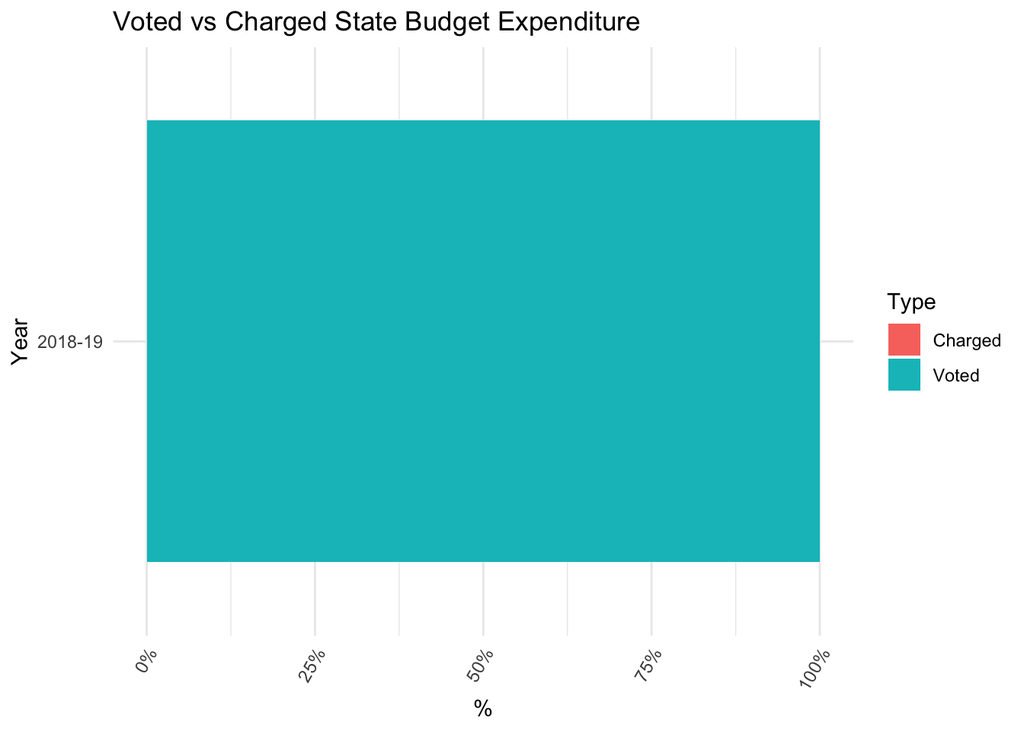

```r
# Voted/Charged
budget_exp_final %>%
        filter(demand_desc == "EDUCATION" & year == "2018-19") %>%
        group_by(year, voted_charged) %>%
        summarise(sanction = sum(sanction)) %>%
        spread(voted_charged, sanction) %>%
        mutate(percent_charged = formattable::percent(C/(V+C)),
               percent_voted = formattable::percent(V/(V+C))) %>%
        select(year, percent_voted, percent_charged) %>%
        gather(Bucket, Percentage, -year) %>%
        ggplot(aes(x = year, y = Percentage, fill = Bucket)) +
                geom_bar(stat = "identity", position = "stack") +
                scale_y_continuous(labels = percent) +
                scale_fill_discrete(name = "Type", labels = c("Charged", "Voted")) +
                labs(title = "Voted vs Charged State Budget Expenditure", x = "Year", y = "%") +
                theme_minimal() + theme(axis.text.x = element_text(angle = 60, vjust = 1, hjust = 1)) +
                coord_flip()
```

All the Himachal Pradesh state expenditure towards education was voted for.

##### **Plan vs Non-Plan**

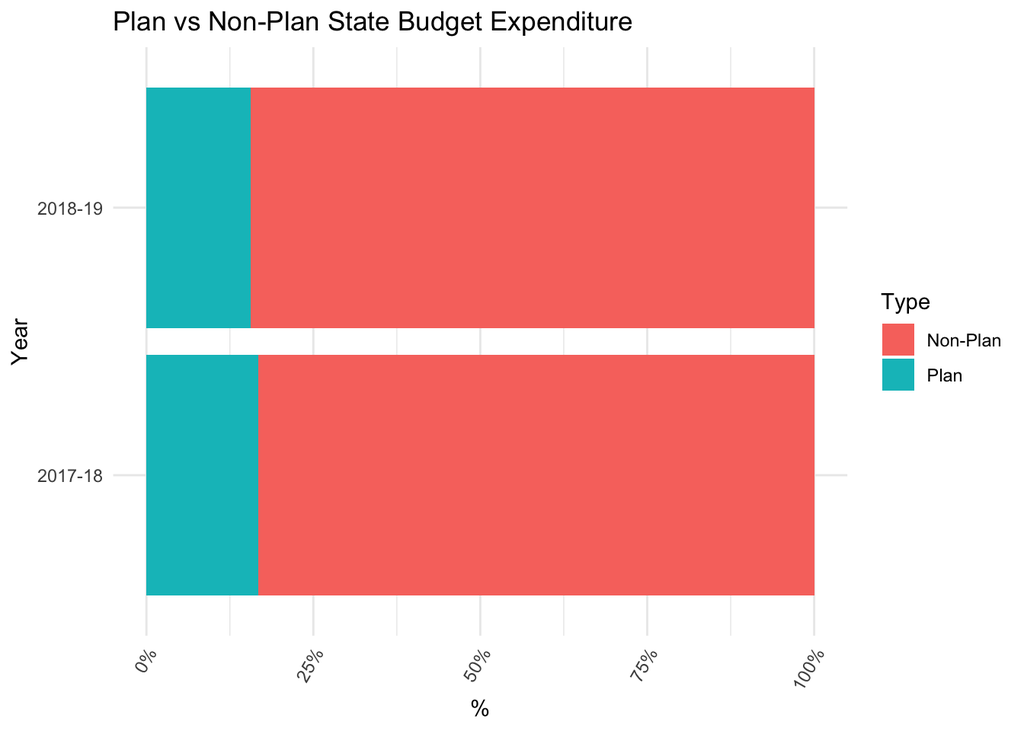

```r
# Plan/Non-Plan
budget_exp_final %>%
        filter(demand_desc == "EDUCATION" ) %>%
        group_by(year, plan_nonplan) %>%
        summarise(sanction = sum(sanction)) %>%
        spread(plan_nonplan, sanction) %>%
        mutate(percent_plan = formattable::percent(P/(N+P)),
               percent_nonplan = formattable::percent(N/(N+P))) %>%
        select(year, percent_plan, percent_nonplan) %>%
        gather(Bucket, Percentage, -year) %>%
        ggplot(aes(x = year, y = Percentage, fill = Bucket)) +
                geom_bar(stat = "identity", position = "stack") +
                scale_y_continuous(labels = percent) +
                scale_fill_discrete(name = "Type", labels = c("Non-Plan", "Plan")) +
                labs(title = "Plan vs Non-Plan State Budget Expenditure", x = "Year", y = "%") +
                theme_minimal() + theme(axis.text.x = element_text(angle = 60, vjust = 1, hjust = 1)) +
                coord_flip()
```

~16% of the state expenditure towards Education was planned and the remaining non-planned.

#### **District Spending**

##### **Overall**

```r
# Quick Summary
education_district_spending_overall <- district_spending_exp_final %>%
            filter(demand_desc == "EDUCATION") %>%
            group_by(year) %>%
            summarise(gross = sum(gross),
                      net_payment = sum(net_payment))

# Rename Fields
names(education_district_spending_overall) <- c("Fiscal Year", "Gross", "Net Payments")

# Print formatted Table
formattable(education_district_spending_overall, list(
                                                    Gross = color_bar("orange"),
                                                    `Net Payments` = color_bar("lightgreen")
                                                    )
            )
```

| Fiscal Year | Gross | Net Payments |
| --- | --- | --- |
| 2017-18 | 51,627,041,691.00 | 36,530,504,601.00 |
| 2018-19 | 52,818,444,554.00 | 38,011,819,739.00 |

- ~4% increase in payments in 2018-19 over 2017-18
- Net payments comprise of ~72% of gross in FY 2018-19; and ~71% in 2017-18

##### **Spending Over Time**

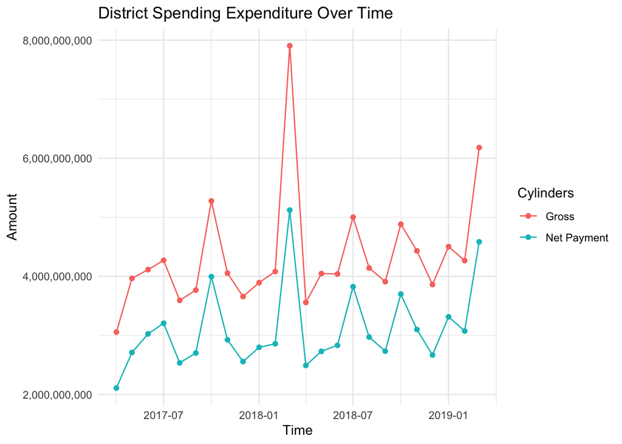

```r
# Trends for budget allocation over time
district_spending_exp_final %>%
    filter(demand_desc == "EDUCATION") %>%
    mutate(month = floor_date(transaction_date, unit = "month")) %>%
    group_by(month) %>%
    summarise(gross = sum(gross),
              net_payment = sum(net_payment)) %>%
    gather(type, amount, -month) %>%
    ggplot(aes(x = month, y = amount, color = type)) +
    geom_line() + geom_point() +
    scale_y_continuous(labels = comma) +
    scale_color_discrete(name = "Cylinders", labels = c("Gross", "Net Payment")) +
    labs(title = "District Spending Expenditure Over Time", x = "Time", y = "Amount") +
    theme_minimal()
```

##### **Top Districts**

```r
# District wise education spending
district_ed <- district_spending_exp_final %>%
    filter(demand_desc == "EDUCATION" & year == "2018-19") %>%
    group_by(district) %>%
    summarise(net_payment = sum(net_payment)) %>%
    arrange(desc(net_payment)) %>%
    mutate(net_payment_total = sum(net_payment)) %>%
    mutate(net_payment_percent = formattable::percent(net_payment/net_payment_total)) %>%
    select(district, net_payment, net_payment_percent)

# Education as % of every district's spending
percent_ed <- district_spending_exp_final %>%
    filter(year == "2018-19") %>%
    mutate(ed_flag = if_else(is.na(demand_desc) | demand_desc != "EDUCATION",
                             "OTHER", "EDUCATION")) %>%
    group_by(ed_flag, district) %>%
    summarise(net_payment = sum(net_payment)) %>%
    spread(ed_flag, net_payment, fill = 0) %>%
    mutate(percent_ed = formattable::percent(EDUCATION/(EDUCATION + OTHER))) %>%
    arrange(desc(EDUCATION)) %>%
    select(district, percent_ed)

# Join the 2 tables
district_wise_ed <- district_ed %>%
                        left_join(percent_ed, by = "district")

# Rename fields
names(district_wise_ed) <- c("District", "Net Payments", "Ed. Share Overall", "Ed. Share District")

# Print formatted table
formattable(district_wise_ed, list(
                                  `Net Payments` = color_bar("lightgreen"),
                                  `Ed. Share Overall` = color_tile("white", "lightblue"),
                                  `Ed. Share District` = color_tile("white", "lightpink")
                                  )
            )
```

| District | Net Payments | Ed. Share Overall | Ed. Share District |
| --- | --- | --- | --- |
| SHIMLA CAPITAL TREASURY | 6,758,700,127.00 | 17.78% | 7.56% |
| DHARAMSALA | 6,222,015,458.00 | 16.37% | 17.45% |
| MANDI | 5,136,877,705.00 | 13.51% | 17.48% |
| SHIMLA | 4,401,083,706.00 | 11.58% | 5.47% |
| SOLAN | 2,556,012,217.00 | 6.72% | 16.51% |
| SIRMAUR | 2,540,670,247.00 | 6.68% | 18.09% |
| CHAMBA | 2,243,848,755.00 | 5.90% | 15.78% |
| HAMIRPUR | 2,153,101,953.00 | 5.66% | 16.80% |
| UNA | 2,114,616,661.00 | 5.56% | 16.07% |
| BILASPUR | 1,967,252,719.00 | 5.18% | 19.34% |
| KULLU | 1,917,295,850.00 | 5.04% | 19.91% |
| KINNAUR | 344,341.00 | 0.00% | 0.01% |

##### **Statement of Expenditure**

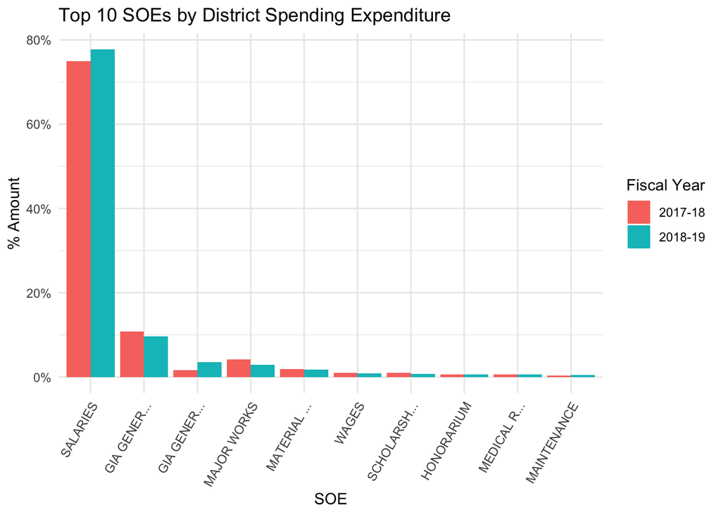

```r
# Education Overall
district_spending_exp_final %>%
    filter(demand_desc == "EDUCATION") %>%
    group_by(year, soe_description) %>%
    summarise(net_payment = sum(net_payment)) %>%
    spread(year, net_payment, fill = 0) %>%
    arrange(desc(`2018-19`)) %>%
    mutate(`Total net_payment (2018-19)` = sum(`2018-19`),
           `Total net_payment (2017-18)` = sum(`2017-18`)) %>%
    mutate(`% of net_payment (2018-19)` = formattable::percent(`2018-19`/`Total net_payment (2018-19)`),
           `% of net_payment (2017-18)` = formattable::percent(`2017-18`/`Total net_payment (2017-18)`)) %>%
    select(soe_description, `% of net_payment (2018-19)`, `% of net_payment (2017-18)`) %>%
    head(10) %>%
    gather(year, percent, -soe_description) %>%
    mutate(soe_description = as_factor(soe_description)) %>%
    ggplot(aes(x = soe_description, y = percent, fill = year)) +
            geom_bar(stat = "identity", position = position_dodge()) +
            scale_x_discrete(label = function(x) stringr::str_trunc(x, 12)) +
            scale_y_continuous(labels = percent) +
            labs(title = "Top 10 SOEs by District Spending Expenditure", x = "SOE", y = "% Amount") +
            scale_fill_discrete(name = "Fiscal Year", labels = c("2017-18", "2018-19")) +
            theme_minimal() + theme(axis.text.x = element_text(angle = 60, vjust = 1, hjust = 1))
```

- ~78% of all education spending was towards salaries.
- 9.6% of spending is towards GIA GENERAL (Salary).

##### **Schemes**

```r
# Education Overall
ed_schemes <- district_spending_exp_final %>%
    filter(demand_desc == "EDUCATION" &
            year == "2018-19" &
            (str_detect(sub_minor_desc, pattern = c("YOJNA")) |
               str_detect(sub_minor_desc, pattern = c("MID DAY")) |
               str_detect(sub_minor_desc, pattern = c("ABHYAN")) |
               str_detect(sub_minor_desc, pattern = c("ABHIYAN")))) %>%
    group_by(sub_minor_desc) %>%
    summarise(net_payment = sum(net_payment)) %>%
    arrange(desc(net_payment))

# Rename fields
names(ed_schemes) <- c("Scheme", "Net Payments")

# Print formatted table
formattable(ed_schemes, list(
                            `Net Payments` = color_bar("lightgreen")
                            )
            )
```

| Scheme | Net Payments |
| --- | --- |
| GRANT- IN- AID- UNDER SARAV SHIKSHA ABHYAN [S10N] | 2,171,986,000.00 |
| RASHTRYA MADHYAMIC SHIKSHA ABHIYAN [S10N] | 883,654,000.00 |
| MID DAY MEAL [S10B] | 649,746,195.00 |
| RASHTRIYA UCHCHATAR SHIKSHA ABHIYAN (RUSA) [S10N] | 254,471,250.00 |
| KALPANA CHAWALA CHATRAVRITI YOJNA [S00N] | 33,055,000.00 |
| MUKHYA MANTRI PROTSAHAN YOJNA [S00N] | 18,375,000.00 |
| MEDHA PROTSAHAN YOJNA [S00N] | 3,500,000.00 |

### **Further Questions**

- In-depth analysis of function and further granularity to identify key spending trends by the education department.
- DDO level analysis to understand gaps in on-ground dissemination of funds to better identify areas of opportunity.
- Comparison of public finance data with further state level population, demographics information to analyse against ground reality.

### **Additional Ideas**

- Develop better understanding from other initiatives exploring public finance data for improvement of child education and open budget explorers to identify key intentions and move learn from the same.
- Understanding the different personas and user journeys on OpenBudgetsIndia by different kind of users & use a data driven approach to customise the platform experience to the user and familiarity with the information at hand.

### **Challenges**

**Sectorial**

- The assignment left me with a lot more questions to answer with my limited knowledge of the financial sector.
- The documentation was helpful in understanding the basic of public finance data; learning from an industry expert would benefit in finding better insights.

**Technical**

- The entire analysis was done using R and the mainly the tidyverse packages.
- Lack of availability of a dashboarding tool created a challenge to replicate some ideas and create narrative in-depth data stories.